# forecast_Project1

Caroline Vickery

2024-02-21

```r
#read in the targets data
targets <- read_csv('https://data.ecoforecast.org/neon4cast-targets/aquatics/aquatics-targets.csv.gz')

# read in the sites data
aquatic_sites <- read_csv("https://raw.githubusercontent.com/eco4cast/neon4cast-targets/main/NEON_Field_Site_Metadata_20220412.csv") |>
  dplyr::filter(aquatics == 1)

lake_sites <- aquatic_sites %>%
  filter(field_site_subtype == 'Lake')

# Filter the targets
targets <- targets %>%
  filter(site_id %in% lake_sites$field_site_id,
         variable == 'temperature')
```

```r
# Past stacked weather
noaa_past_s3 <- neon4cast::noaa_stage3()

variables <- c("air_temperature", "relative_humidity", "eastward_wind", "northward_wind")
#Other variable names can be found at https://projects.ecoforecast.org/neon4cast-docs/Shared-Forecast-Drivers.html#stage-3

noaa_past <- noaa_past_s3  |>
  dplyr::filter(site_id %in% lake_sites$field_site_id,
                datetime >= ymd('2017-01-01'),
                variable %in% variables) |>
  dplyr::collect()

# aggregate the past to mean values
noaa_past_mean <- noaa_past |>
  mutate(datetime = as_date(datetime)) |>
  group_by(datetime, site_id, variable) |>
  summarize(prediction = mean(prediction, na.rm = TRUE), .groups = "drop") |>
  pivot_wider(names_from = variable, values_from = prediction) |>
  # convert air temp to C
  mutate(air_temperature = air_temperature - 273.15)

noaa_past_mean$windspeed<-sqrt(noaa_past_mean$eastward_wind^2 + noaa_past_mean$northward_wind^2)
```

```r
# Future weather
# New forecast only available at 5am UTC the next day
forecast_date <- Sys.Date()
noaa_date <- forecast_date - days(1)

noaa_future_s3 <- neon4cast::noaa_stage2(start_date = as.character(noaa_date))
variables <- c("air_temperature", "relative_humidity", "eastward_wind", "northward_wind")

noaa_future <- noaa_future_s3 |>
  dplyr::filter(datetime >= forecast_date,
                site_id %in% lake_sites$field_site_id,
                variable %in% variables) |>
  collect()

noaa_future_daily <- noaa_future |>
  mutate(datetime = as_date(datetime)) |>
  # mean daily forecasts at each site per ensemble
  group_by(datetime, site_id, parameter, variable) |>
  summarize(prediction = mean(prediction)) |>
  pivot_wider(names_from = variable, values_from = prediction) |>
  # convert to Celsius
  mutate(air_temperature = air_temperature - 273.15)

noaa_future_daily$windspeed<-sqrt(noaa_future_daily$eastward_wind^2 + noaa_future_daily$northward_wind^2)

combined_met_df1 <- bind_rows(noaa_past_mean, noaa_future_daily)

jasontest<-combined_met_df1 %>%
  arrange(site_id, parameter, datetime) %>%
  group_by(site_id, parameter) %>%
  mutate(airtemp_1daylag = lag(air_temperature)) #correct way to lag
jasontest$datetime_lagged<-jasontest$datetime - days(1)
derulotest<-jasontest

#filling in the gaps - Sys.Date data is missing airtemp_1daylag
cyrus_df<-NULL


for(i in 1:length(lake_sites$field_site_id)){
  curr_site <- lake_sites$field_site_id[i]

  currentrow<-derulotest %>% filter(datetime==Sys.Date(),
                site_id==curr_site,
                airtemp_1daylag!=is.na(airtemp_1daylag))

  airtemptopaste<-currentrow$airtemp_1daylag #yesterday's measured air temp

  mileytest<-derulotest %>% filter(datetime==Sys.Date(),
                                 site_id==curr_site) %>%
    select(datetime, site_id, parameter, airtemp_1daylag, datetime_lagged)

  party<-mileytest %>% filter(parameter>=0)

  party$airtemp_1daylag<-airtemptopaste
  #party$realdatetime<-realdatetopaste

  cyrus_df<-dplyr::bind_rows(party, cyrus_df)
}


derulotest2<-left_join(derulotest, cyrus_df, by=c("datetime", "site_id", "parameter", "datetime_lagged"))

derulotest2<-derulotest2 %>% select(order(colnames(.))) %>% unite("airtemp_1daylag", airtemp_1daylag.x:airtemp_1daylag.y, na.rm = TRUE, remove = FALSE)

derulotest2<-derulotest2 %>% select(-c(airtemp_1daylag.x, airtemp_1daylag.y))

derulotest2$airtemp_1daylag<-as.numeric(derulotest2$airtemp_1daylag)
```

```r
# Generate a dataframe to fit the model to
targets_lm <- targets |>
  filter(variable == 'temperature') |>
  pivot_wider(names_from = 'variable', values_from = 'observation') |>
  right_join(derulotest2,
            by = c("datetime","site_id"))
```

```r
forecast_horizon <- 30
forecast_dates <- seq(from = ymd(forecast_date), to = ymd(forecast_date) + forecast_horizon, by = "day")
n_members <- 30

forecast_df <- NULL


for(i in 1:length(lake_sites$field_site_id)) {

  curr_site <- lake_sites$field_site_id[i]

  # Get only the necessary data for the specific site
  site_target <- targets_lm |>
    filter(site_id == curr_site,
           datetime <= ymd(forecast_date),
           is.na(parameter))

  site_target2<- site_target  %>%
  arrange(site_id, parameter, datetime) %>%
  group_by(site_id, parameter) %>%
  mutate(watertemp_1daylag = lag(temperature),
         rownumber=c(1:nrow(site_target)))


  noaa_future_site <- derulotest2 |>
    filter(site_id == curr_site,
           datetime >= ymd(forecast_date),
           datetime <= ymd(forecast_date) + forecast_horizon,
           parameter != is.na(parameter)) %>%
  mutate(watertemp_1daylag = NA,
         temp_prediction = NA)
  noaa_future_site$rownumber<-1:nrow(noaa_future_site)

  #Fit linear model based on past data: water temperature = m * air temperature + b
  fit <- lm(site_target2$temperature ~ site_target2$air_temperature + site_target2$watertemp_1daylag + site_target2$windspeed)

  #parameter uncertainty
  summary_fit<-summary(fit)
coeffs <- round(fit$coefficients, 3)

params_se <- summary_fit$coefficients[,2]

param_df <- data.frame(beta1 = rnorm(n_members, coeffs[1], params_se[1]),
                       beta2 = rnorm(n_members, coeffs[2], params_se[2]),
                       beta3 = rnorm(n_members, coeffs[3], params_se[3]),
                       beta4 = rnorm(n_members, coeffs[4], params_se[4]))

#process uncertainty
mod <- predict(fit, site_target2)
residuals <- mod - site_target2$temperature

sigma <- sd(residuals, na.rm = TRUE) # Process Uncertainty Noise Std Dev.; this is your sigma

#attempt to backcast
site_target2_todaylag<-site_target2  %>% filter(temperature!=is.na(temperature)) %>%  slice(which.max(as.Date(datetime, '%m/%d/%Y')))

backcast_dates<-seq(from = ymd(site_target2_todaylag$datetime) +1, to = ymd(forecast_date), by = "day")


  if (site_target2_todaylag$datetime!=Sys.Date()) {
    for (j in 1:length(backcast_dates)){

      site_drivers_back <- site_target2 %>%
    filter(datetime == backcast_dates[j])

      currentrow<-site_target2 %>%
    filter(datetime == backcast_dates[j]) %>%
        select(c("rownumber", "site_id", "parameter"))

      backcast_temp <- fit$coefficients[1] +
        fit$coefficients[2] * site_drivers_back$air_temperature +  fit$coefficients[3] * site_drivers_back$watertemp_1daylag + fit$coefficients[4] * site_drivers_back$windspeed

      site_target2$temperature[currentrow$rownumber]<-backcast_temp

      site_target2<- site_target2  %>%
        mutate(watertemp_1daylag = lag(temperature))
    }
    message('backcast for ', curr_site, ' run')
  }

firstfuture<-site_target2 %>% filter(datetime==Sys.Date()) %>% select(watertemp_1daylag, site_id, parameter)
firstfuturetopaste<-firstfuture$watertemp_1daylag


currentrow2<-noaa_future_site %>%
    filter(datetime == Sys.Date()) %>%
        select(c("rownumber", "site_id", "parameter", "datetime"))
currentrow2.vec<-as.vector(currentrow2$rownumber)

for(v in currentrow2.vec){
  noaa_future_site$watertemp_1daylag[v]<-firstfuturetopaste
}

creatingspace<-NULL
filledspace<-NULL
  # Loop through all forecast dates
  for (t in 1:length(forecast_dates)) {

  #pull driver ensemble for the relevant date; here we are using all 30 NOAA ensemble members
  site_drivers <- noaa_future_site %>%
    filter(datetime == forecast_dates[t])

  # use linear regression to forecast water temperature for each ensemble member
  forecasted_temperature <- param_df$beta1 + param_df$beta2 * site_drivers$air_temperature + param_df$beta3 * site_drivers$watertemp_1daylag + param_df$beta4 * site_drivers$windspeed + rnorm(n_members, mean = 0, sd = sigma)

  # put all the relevant information into a tibble that we can bind together
  curr_site_df <- tibble(datetime = rep(forecast_dates[t], times = n_members),
                         site_id = curr_site,
                         parameter = 1:n_members,
                         prediction = forecasted_temperature,
                         variable = "temperature")

  forecast_df <- dplyr::bind_rows(forecast_df, curr_site_df)


  #feeding the next loop run
for(u in 1:nrow(curr_site_df)){
  forecasttopaste<-curr_site_df$prediction[u]
  parameterforfilter<-curr_site_df$parameter[u]

  creatingspace2<-noaa_future_site %>%
    filter(datetime==forecast_dates[t],
           parameter==parameterforfilter)

  creatingspace2$temp_prediction<-forecasttopaste

  filledspace<-dplyr::bind_rows(filledspace, creatingspace2)
}

binders<-noaa_future_site %>% select(-c(temp_prediction)) %>% colnames()
noaa_future_site<-left_join(noaa_future_site, filledspace,
                            by=binders)

noaa_future_site$temp_prediction <- ifelse(is.na(noaa_future_site$temp_prediction.x), noaa_future_site$temp_prediction.y, noaa_future_site$temp_prediction.x)

noaa_future_site<-noaa_future_site %>% select(-c(temp_prediction.x, temp_prediction.y))

noaa_future_site$temp_prediction<-as.numeric(noaa_future_site$temp_prediction)

   noaa_future_site<- noaa_future_site  %>%
         mutate(watertemp_1daylag = lag(temp_prediction))

   backfill<-noaa_future_site %>%
    filter(datetime == Sys.Date())


   if(is.na(noaa_future_site$watertemp_1daylag[1])){
     currentrow2<-noaa_future_site %>%
    filter(datetime == Sys.Date()) %>%
        select(c("rownumber", "site_id", "parameter", "datetime"))
currentrow2.vec<-as.vector(currentrow2$rownumber)

for(v in currentrow2.vec){
  noaa_future_site$watertemp_1daylag[v]<-firstfuturetopaste
}
   }

     }

  message(curr_site, 'forecast run')
}
```

```
## backcast for BARC run
```

```
## BARCforecast run
```

```
## backcast for CRAM run
```

```
## CRAMforecast run
```

```
## backcast for LIRO run
```

```
## LIROforecast run
```

```
## backcast for PRLA run
```

```
## PRLAforecast run
```

```
## backcast for PRPO run
```

```
## PRPOforecast run
```

```
## backcast for SUGG run
```

```
## SUGGforecast run
```

```
## backcast for TOOK run
```

```
## TOOKforecast run
```

```r
# Make forecast fit the EFI standards
# Remember to change the model_id when you make changes to the model structure!
my_model_id <- 'lm_AT_WTL_WS'

forecast_df_EFI <- forecast_df %>%
  filter(datetime > forecast_date) %>%
  mutate(model_id = my_model_id,
         reference_datetime = forecast_date,
         family = 'ensemble',
         parameter = as.character(parameter)) %>%
  select(datetime, reference_datetime, site_id, family, parameter, variable, prediction, model_id)
```

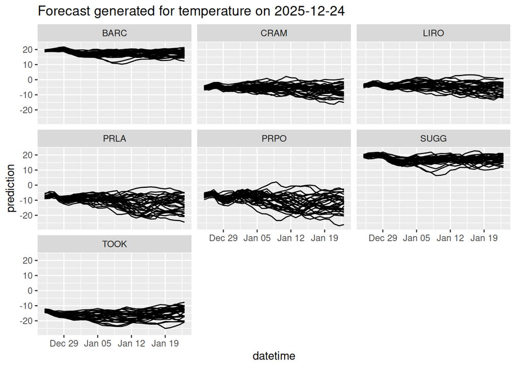

```r
forecast_df_EFI |>
  ggplot(aes(x=datetime, y=prediction, group = parameter)) +
  geom_line() +
  facet_wrap(~site_id) +
  labs(title = paste0('Forecast generated for ', forecast_df_EFI$variable[1], ' on ', forecast_df_EFI$reference_datetime[1]))
```

```r
# Write the forecast to file
theme <- 'aquatics'
date <- forecast_df_EFI$reference_datetime[1]
forecast_name_1 <- paste0(forecast_df_EFI$model_id[1], ".csv")
forecast_file_1 <- paste(theme, date, forecast_name_1, sep = '-')
forecast_file_1
```

```
## [1] "aquatics-2025-12-24-lm_AT_WTL_WS.csv"
```

```r
if (!dir.exists('Forecasts')) {
  dir.create('Forecasts')
}

write_csv(forecast_df_EFI, file.path('Forecasts',forecast_file_1))

neon4cast::forecast_output_validator(file.path('Forecasts',forecast_file_1))
```

```
## Forecasts/aquatics-2025-12-24-lm_AT_WTL_WS.csv
```

```
## ✔ file has model_id column
## ✔ only one unique value in the model_id column
## ✔ forecasted variables found correct variable + prediction column
## ✔ temperature is a valid variable name
## ✔ file has correct family and parameter columns
## ✔ only one unique value in the family column
## ✔ file has site_id column
## ✔ file has datetime column
## ✔ file has correct datetime column
```

```
## ✔ file has reference_datetime column
## Forecast format is valid
```

```
## [1] TRUE
```

```r
## # can uses the neon4cast::forecast_output_validator() to check the forecast is in the right format

# UNCOMMMENT THIS WHEN YOU ARE READY TO SUBMIT
neon4cast::submit(forecast_file = file.path('Forecasts', forecast_file_1),                   ask = F) # if ask = T (default), it will produce a pop-up box asking if you want to submit
```

```
## validating that file matches required standard
```

```
## Forecasts/aquatics-2025-12-24-lm_AT_WTL_WS.csv
```

```
## ✔ file has model_id column
## ✔ only one unique value in the model_id column
## ✔ forecasted variables found correct variable + prediction column
## ✔ temperature is a valid variable name
## ✔ file has correct family and parameter columns
## ✔ only one unique value in the family column
## ✔ file has site_id column
## ✔ file has datetime column
## ✔ file has correct datetime column
```

```
## ✔ file has reference_datetime column
## Forecast format is valid
##
## Thank you for submitting!
```

This forecast of water temperature at NEON Lake sites uses a linear model, incorporating air temperature, wind speed, and the previous day’s forecasted water temperature as variables. Air temperature is incorporated from NEON’s data and forecast. Wind speed is calculated based on eastern and northern wind speeds from NEON’s data and forecast. I used the Pythagorean theorem to calculate wind speed based on the directional wind vectors.

Calculating the water temperature lag required first a backcast of water temperature from the last recorded water temperature from NEON. I used the same model coefficients fitted to the original data to forecast water temperature to present day without uncertainty. This backcasting incorporates initial condition uncertainty to the water temperature forecast, even though the forecast starts with only one initial condition.

In addition to initial condition uncertainty, the linear model forecast incorporates process uncertainty, parameter uncertainty, and driver uncertainty. I used the linear model fit to estimate the standard deviation, which accounts for process uncertainty in how the data is represented. I used the linear model fit to generate 30 parameters based to include parameter uncertainty. Lagged water temperature is calculated in the forecast according to parameter, for each date and for each site. This forecast also includes driver uncertainty, as I am using variables to build my forecast.

This forecast uses air temperature, wind speed, and 1-day lagged water temperature as variables. I chose these drivers after also considering relative humidity and 1-day lagged air temperature. After trying every combination of these variables in different linear models fit to the target data, the combination of air temperature, wind speed, and lagged water temperature produced the model with the highest R^2 value (0.9882). When I added relative humidity to the model, relative humidity was an insignificant driver. Models with lagged air temperature had lower R^2 values compared to models with unlagged air temperature. Adding lagged water temperature improved the R^2 for the model and, therefore, improved the forecast.